# Lecture 14

Data Visualization - Bar Charts

Byeong-Hak Choe

bchoe@geneseo.edu

SUNY Geneseo

March 21, 2024

## RStudio Workflow

### Must-know Quarto Shortcuts

### Mac

- **option + command + I**: to create a R chunk
- **option + -** : the shortcut for `<-`
- **command + return** runs a current line or selected lines
- **command + shift + return**: to run the code in the R chunk
- **command + shift + C**: to comment out a line
- **command + shift + K**: to render a current Quarto file

### Windows

- **Alt+Ctrl+I** : to create a R chunk
- **Alt + -** : the shortcut for `<-`
- **Ctrl + Enter** runs a current line or selected lines
- **Ctrl + Shift + Enter** : to run the code in the R chunk
- **Ctrl + Shift + C**: to comment out a line
- **Ctrl + Shift + K**: to render a current Quarto file

## Documenting Workflow

### Must-know Shortcuts

- Use the shortcuts below whenever you edit a document, including Quarto:

### Mac

- **command + ⬆️/⬇️/⬅️/➡️**
- **shift + ⬆️/⬇️/⬅️/➡️**
- **command + shift + ⬆️/⬇️/⬅️/➡️**
- **command + PgUp/PgDn**
- **shift + PgUp/PgDn**
- **command + shift + PgUp/PgDn**:

### Windows

- **Ctrl + ⬆️/⬇️/⬅️/➡️**
- **Shift + ⬆️/⬇️/⬅️/➡️**
- **Ctrl + shift + ⬆️/⬇️/⬅️/➡️**
- **Ctrl + PgUp/PgDn**
- **Shift + PgUp/PgDn**
- **Ctrl + Shift + PgUp/PgDn**:

## `ggplot` Basics

### Learning Objectives

- Log Functions
- Statistical Transformation
- Bar Charts

## A Little Bit of Math for `log()`

- log functions
- log examples
- The logarithm function, $y = \log_{b}\,(\,x\,)$, looks like ….

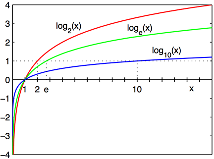

- $\log_{10}\,(\,100\,)$: the base $10$ logarithm of $100$ is $2$, because $10^{2} = 100$
- $\log_{e}\,(\,x\,)$: the base $e$ logarithm is called the natural log, where $e = 2.718\cdots$ is the mathematical constant, the Euler’s number.
- $\log\,(\,x\,)$ or $\ln\,(\,x\,)$: the natural log of $x$ .
- $\log_{e}\,(\,7.389\cdots\,)$: the natural log of $7.389\cdots$ is $2$, because $e^{2} = 7.389\cdots$.

## The use of `log()`

### NYC Housing Sales

```r
library(tidyverse)
sale_df <- read_csv(
  "https://bcdanl.github.io/data/home_sales_nyc.csv")
```

- `sale_df` contains data for residential property sales from September 2017 and August 2018 in NYC.
  - Let’s focus on `sale.price`, a property’s sales price.

## The use of `log()`

### Percentage Change

**1**. We should consider using a logarithmic scale when percent change, or change in orders of magnitude, is more important than changes in absolute units.

- For small changes in variable $x$ from $x_{0}$ to $x_{1}$, the following can be shown:

$$\Delta \log(x) \,= \, \log(x_{1}) \,-\, \log(x_{0})
\approx\, \frac{x_{1} \,-\, x_{0}}{x_{0}}
\,=\, \frac{\Delta\, x}{x_{0}}.$$

- For example, a difference in `sale.price` of $10,000 means something very different across people with different income/wealth levels.

## The use of `log()`

### Wide Range of Skewed Data

**2**. We should consider using a log scale when a variable is heavily skewed. - It can help visualize both small and large values effectively.

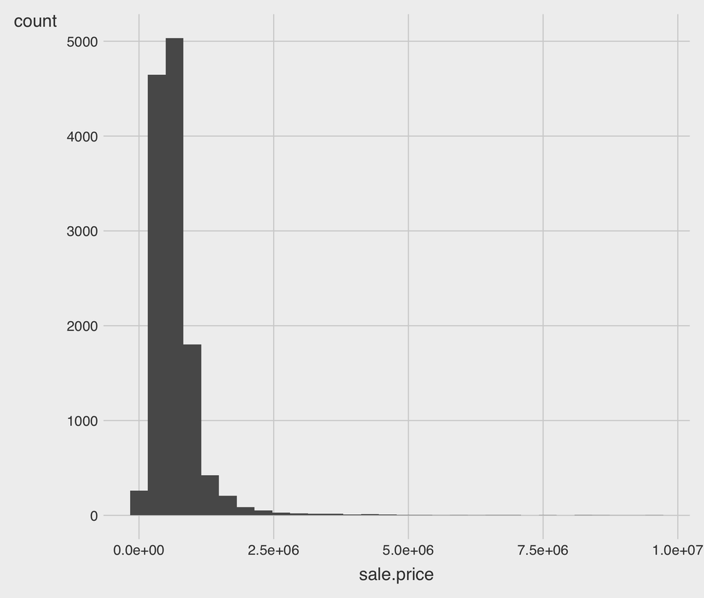

```r
ggplot(sale_df,
       aes(x = sale.price),
       bins = 500) +
  geom_histogram()
```

# Statistical Transformation

## Statistical Transformation

- Many graphs, including bar charts, calculate *new values* to plot:
  - `geom_bar()`, `geom_histogram()`, and `geom_freqpoly()` bin our data and then plot bin counts, the number of observations that fall in each bin.
  - `geom_boxplot()` computes a summary of the distribution and then display a specially formatted box.
  - `geom_smooth()` fits a model to our data and then plot predictions from the model.

## Statistical Transformation

- Bar charts seem simple, but they are interesting because they reveal something subtle about plots.
- Consider a basic bar chart, as drawn with `geom_bar()`.
- The following bar chart displays the total number of diamonds in the `ggplot2::diamonds` data.frame, grouped by `cut`.
- The `diamonds` data.frame comes in `ggplot2` and contains information about ~54,000 diamonds, including the `price`, `carat`, `color`, `clarity`, and `cut` of each diamond.

## Statistical Transformation

- `geom_bar()` bins our data and then plot bin counts, the number of observations that fall in each bin.

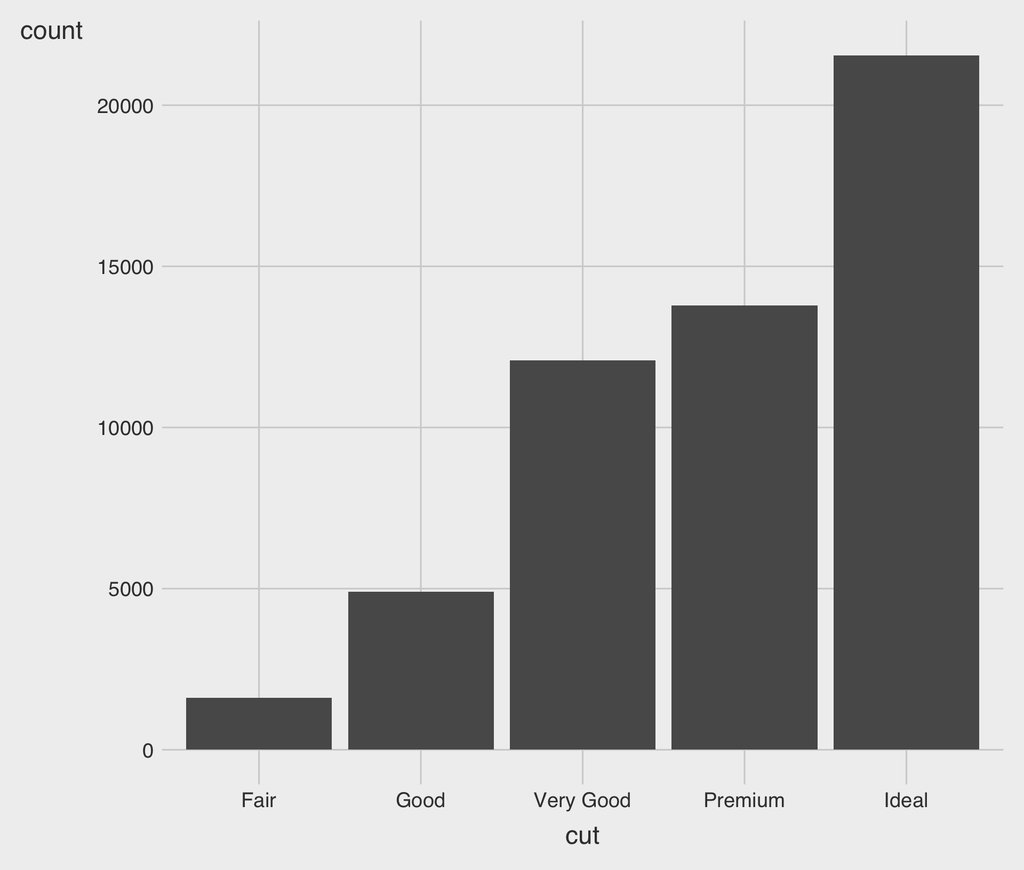

```r
ggplot(data = diamonds) +
  geom_bar(mapping = aes(x = cut))
```

## Statistical Transformation

### Observed Value vs. Number of Observations

- There are three reasons we might need to use a `stat` explicitly:
  1. We might want to override the default `stat`.
  2. We might want to override the default `stat()`
  3. We might want to use `stat_summary()`.

## Statistical Transformation

### Observed Value vs. Number of Observations

- *1*. We might want to override the default `stat`.

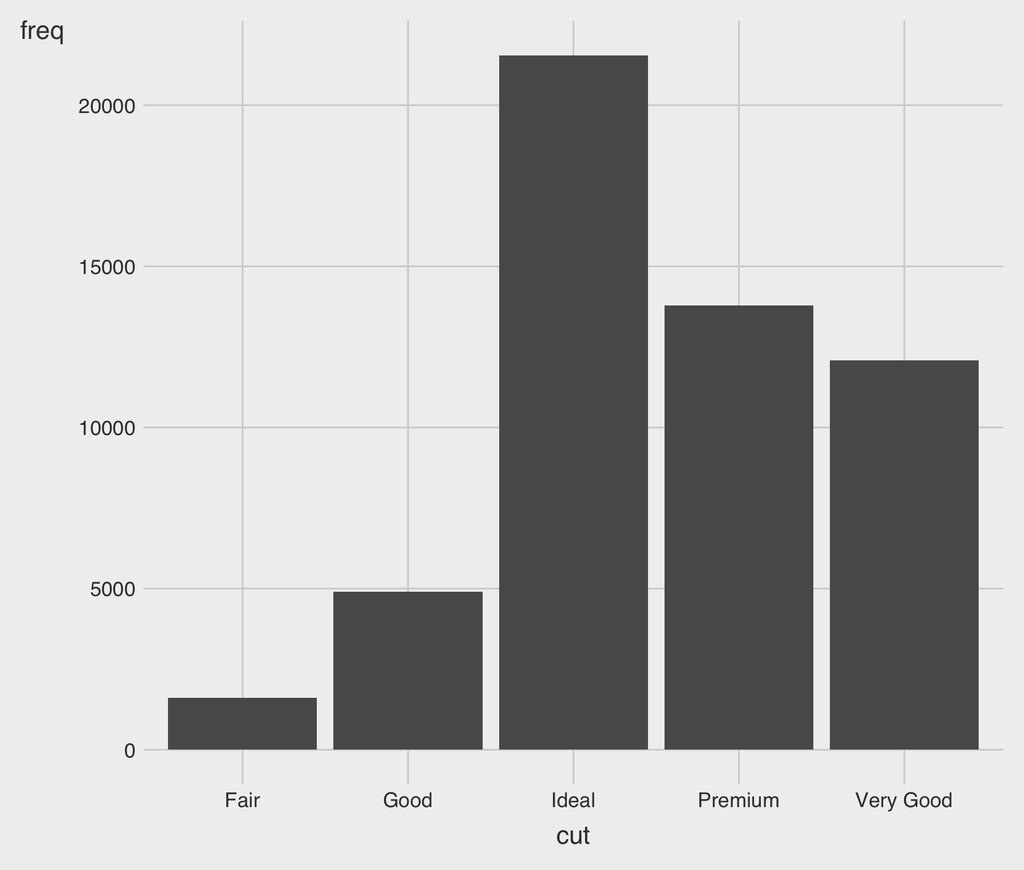

```r
# to make a simple data.frame
demo <- tribble(
  ~cut,         ~freq,
  "Fair",       1610,
  "Good",       4906,
  "Very Good",  12082,
  "Premium",    13791,
  "Ideal",      21551 )

ggplot(data = demo) +
  geom_bar(mapping =
             aes(x = cut,
                 y = freq),
           stat = "identity")
```

## Statistical Transformation

### Count vs. Proportion

- *2*. We might want to override the default `stat()`

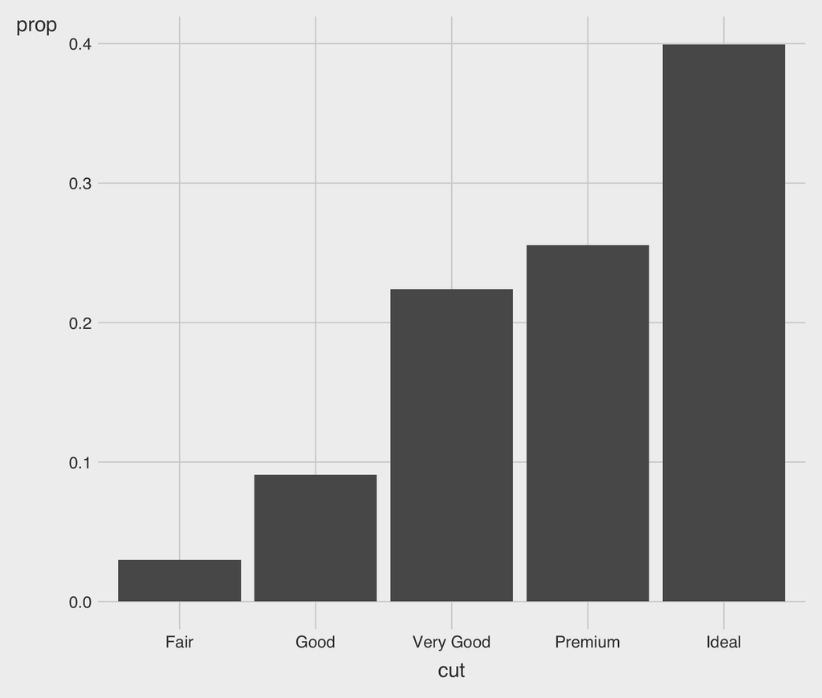

```r
ggplot(data = diamonds) +
  geom_bar(mapping =
             aes(x = cut,
                 y = stat(prop),
                 group = 1))
```

## Statistical Transformation

### Stat summary

- *3*. We might want to use `stat_summary()`.

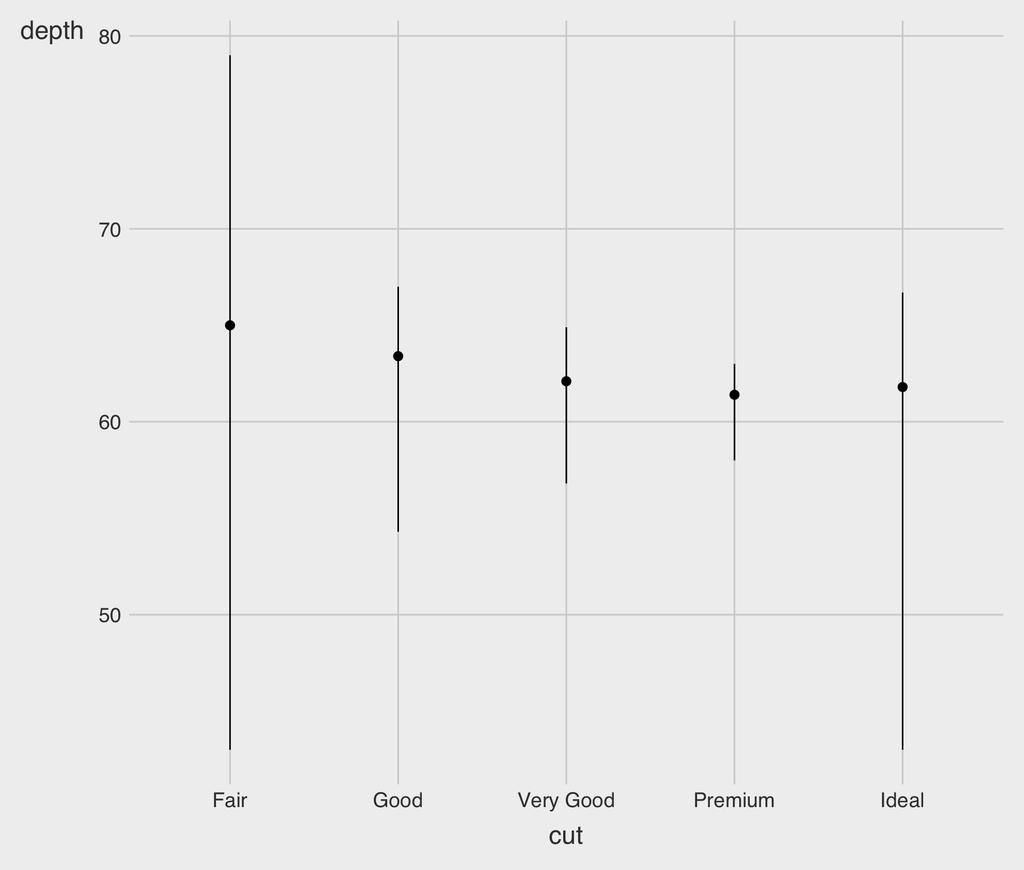

```r
ggplot(data = diamonds) +
  stat_summary(
    mapping = aes(x = cut, y = depth),
    fun.min = min,
    fun.max = max,
    fun = median
  )
```

# Position Adjustment

## Position Adjustment

### `color` and `fill` aesthetic

- We can color a bar chart using either the `color` aesthetic, or, more usefully, `fill`.

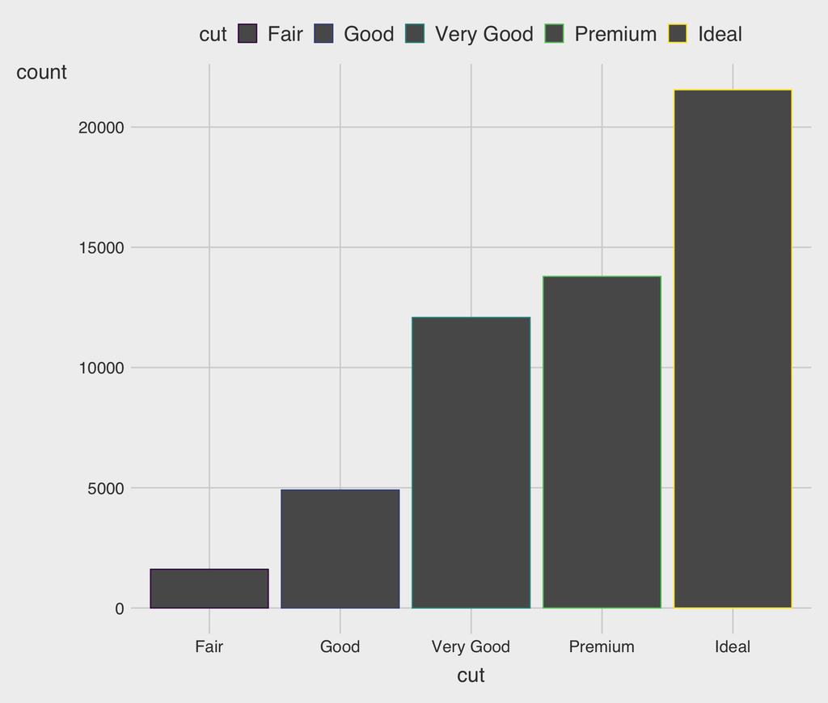

```r
ggplot(data = diamonds) +
  geom_bar(mapping =
             aes(x = cut,
                 color = cut))
```

## Position Adjustment

### `fill`

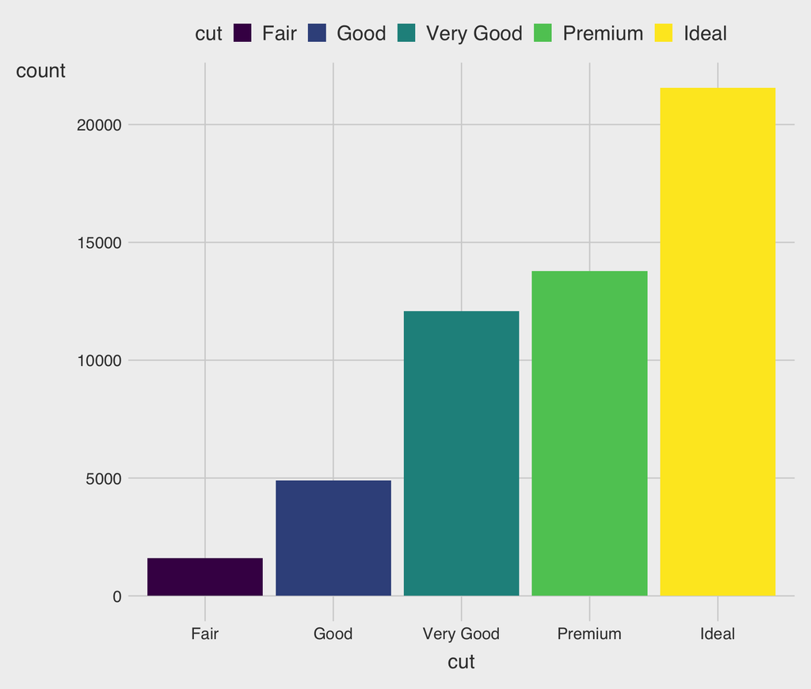

```r
ggplot(data = diamonds) +
  geom_bar(mapping =
             aes(x = cut,
                 fill = cut))
```

## Position Adjustment

### Stacked bar charts with `fill` aesthetic

- Note that the bars are automatically stacked if we map the `fill` aesthetic to another variable.

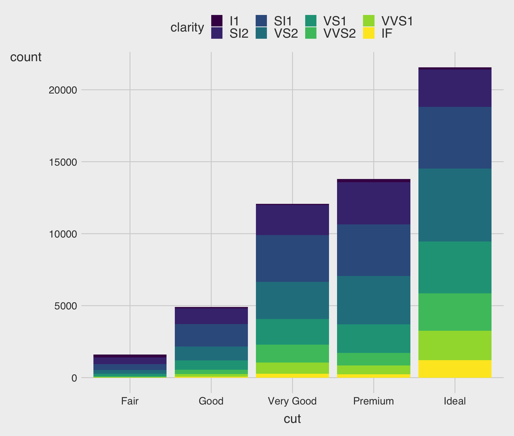

```r
ggplot(data = diamonds) +
  geom_bar(mapping =
             aes(x = cut,
                 fill = clarity) )
```

## Position Adjustment

### Stacked bar charts with `fill` aesthetic

- The `stack`ing is performed automatically by the **position adjustment** specified by the `position` argument.

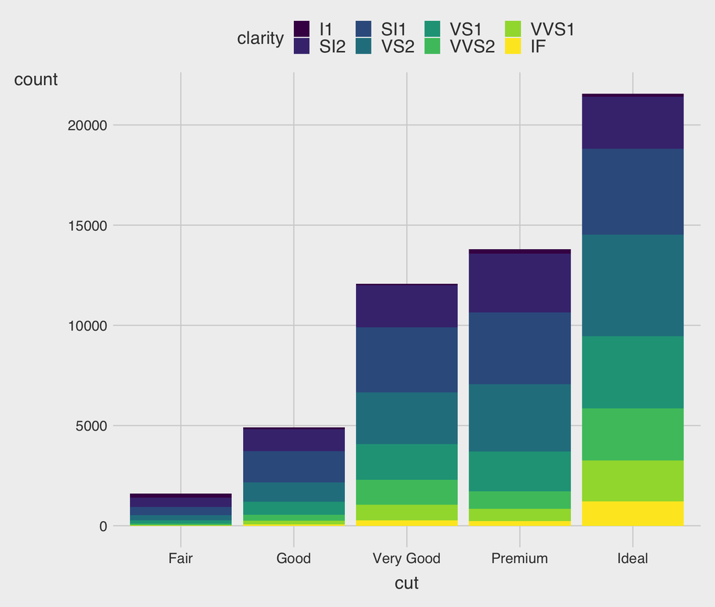

```r
ggplot(data = diamonds) +
  geom_bar(mapping =
             aes(x = cut,
                 fill = clarity),
           position = "stack")
```

## Position Adjustment

- If we don’t want a stacked bar chart with counts, we can use one of two other `position` options: `fill` or `dodge`.
- `position = "fill"` works like stacking, but makes each set of stacked bars the same height.
  - This makes it easier to compare proportions across groups.
- `position = "dodge"` places overlapping objects directly beside one another.

## Position Adjustment

### `position = "fill"`

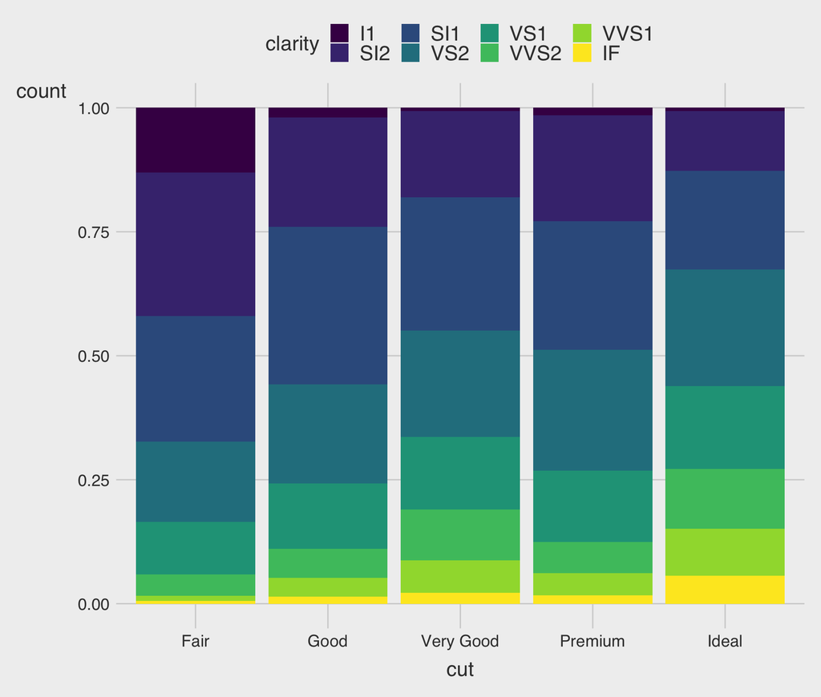

```r
ggplot(data = diamonds) +
  geom_bar(mapping =
             aes(x = cut,
                 fill = clarity),
           position = "fill")
```

## Position Adjustment

### `position = "dodge"`

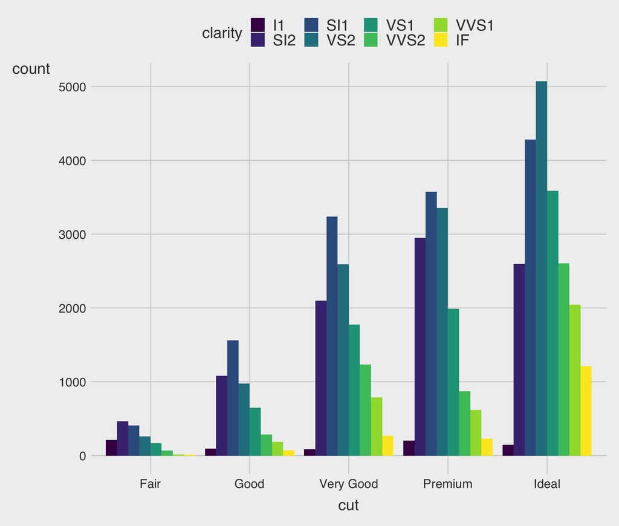

```r
ggplot(data = diamonds) +
  geom_bar(mapping =
             aes(x = cut,
                 fill = clarity),
           position = "dodge")
```

# Coordinate Systems

## Coordinate Systems

### `geom_abline()`

- What does `geom_abline()` do?

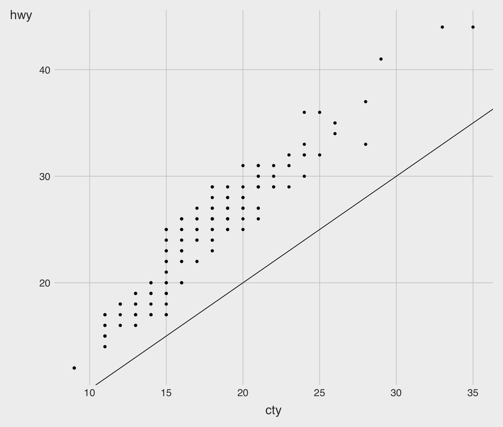

```r
ggplot(data = mpg,
       mapping =
         aes(x = cty,
             y = hwy)) +
  geom_point() +
  geom_abline() # math: y = ax + b
```

## Coordinate Systems

### `coord_fixed()`

- What does `coord_fixed()` do?

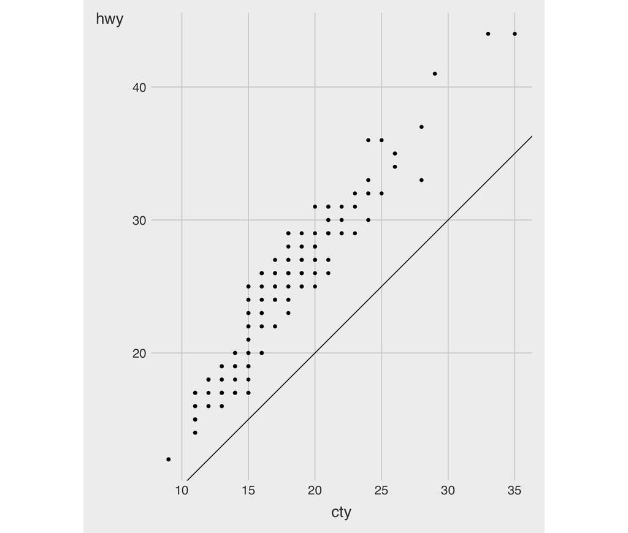

```r
ggplot(data = mpg,
       mapping =
         aes(x = cty,
             y = hwy)) +
  geom_point() +
  geom_abline() +
  coord_fixed()
```

# The Layered `G`rammar of `G`raphics (`ggplot`)

# The Layered Grammar of Graphics

```r
ggplot(data = <DATA>) +
  <GEOM_FUNCTION>(
     mapping = aes(<MAPPINGS>),
     stat = <STAT>,
     position = <POSITION>) +
  <FACET_FUNCTION> +
  <COORDINATE_FUNCTION>
```

- Above summarizes the layered grammar of graphics—faceting, stats, position adjustments, and, coordinate systems.